# Birth weight - Heritability estimate and GWAS

Caelinn James

21 March 2021

**Written for R 4.0.2, last updated 01/07/21**

### Load packages

```r
library(RODBC)
library(data.table)
library(stringr)
library(splitstackshape)
library(qqman)
```

### Connect to the database

Note that from database front end version 2.22, it is important to click “Make R Friendly” in the queries section before running the analysis, or loading the pedigree will not work (will not work at all for prior front end versions)

```r
dv <- "C:/Users/s1944058/Documents/Sheep/Database/SoaySheep2.30.accdb"
con <- odbcConnectAccess2007(dv)
tbls <- sqlTables(con)
sheep <- sqlFetch(con,"sys_SheepPlusBirthInfo")
```

Check to see if the sheep file has loaded correctly (don’t worry about negative IDs or lots of NAs)…

```r
head(sheep)
```

```
##      ID BirthRef MumSource Status Sex Coat Horn BirthYear BirthMonth BirthDay
## 1 -2644    11143         3  Dummy   2   NA   NA        NA         NA       NA
## 2 -2643       NA        NA  Dummy   2   NA   NA        NA         NA       NA
## 3 -2642    11142         3  Dummy   2   NA   NA        NA         NA       NA
## 4 -2641       NA        NA  Dummy   2   NA   NA        NA         NA       NA
## 5 -2640       NA        NA  Dummy   2   NA   NA        NA         NA       NA
## 6 -2639       NA        NA  Dummy   2   NA   NA        NA         NA       NA
##   MumID BirthWt CapAge BirthEasting BirthNorthing SibCount SibNoObserved TwinID
## 1  4106      NA     NA           NA            NA        0             0     NA
## 2    NA      NA     NA           NA            NA        0             0     NA
## 3 10114      NA     NA           NA            NA        0             0     NA
## 4    NA      NA     NA           NA            NA        0             0     NA
## 5    NA      NA     NA           NA            NA        0             0     NA
## 6    NA      NA     NA           NA            NA        0             0     NA
##   TripletID DeathYear DeathMonth DeathDay DeathType DeathEasting DeathNorthing
## 1        NA        NA         NA       NA        NA           NA            NA
## 2        NA        NA         NA       NA        NA           NA            NA
## 3        NA        NA         NA       NA        NA           NA            NA
## 4        NA        NA         NA       NA        NA           NA            NA
## 5        NA        NA         NA       NA        NA           NA            NA
## 6        NA        NA         NA       NA        NA           NA            NA
##   InCleitDeath
## 1           NA
## 2           NA
## 3           NA
## 4           NA
## 5           NA
## 6           NA
```

### Filter the data

Remove sheep that do not have their birth weight recorded

```r
births <- sheep[!(is.na(sheep$BirthWt)),]
```

Remove sheep born 1985 or earlier

```r
births <- births[which(births$BirthYear>1985),]
```

Remove sheep that do not have their capture age recorded, or were weighed younger than 2 days (as these sheep were likely already dead), or older than 10 days (as the relationship between age and weight stops being linear at this point)

```r
births <- births[!(is.na(births$CapAge)),]
births <- births[-(which(births$CapAge < 2|births$CapAge >10)),]
```

Remove any sheep who died within one month of being born

```r
births <- births[-(which(births$BirthYear == births$DeathYear & births$BirthMonth == births$DeathMonth) ),]
```

```r
SNPs_50K <- read.table("C:/Users/s1944058/Documents/Sheep/50KSNP/Plates_1to87_QC3.fam")
births <- births[which(births$ID %in% SNPs_50K$V2),]
SNPs_HD <- read.table("C:/Users/s1944058/Documents/Sheep/HDSNP/sheep_geno_imputed_oar31_17052020.fam")
births <- births[which(births$ID %in% SNPs_HD$V2),]
```

### Correct birth weight for the age of the sheep when weighed

As the remaining sheep in our data were caught at different ages (between 2 - 10 days old), and the relationship between age and weight is linear at this point (a growth of 0.108kg a day), it is important to correct the birth weight of the sheep for how old it was when caught

```r
births$BirthWtCorrected <- births$BirthWt - (births$CapAge * 0.108)
```

### Filter data for the model

Birth date (what day in the year they were born on)

```r
births$BirthDate <- paste0(births$BirthYear,"/",births$BirthMonth,"/",births$BirthDay)
births$Date[!is.na(births$BirthMonth)] <- as.numeric(format(as.Date(births[!is.na(births$BirthMonth),"BirthDate"]),"%j"))
```

Change the notation of castrated males to normal males (no need to differentiate for this model) and remove sheep with no sex recorded

```r
births$Sex[births$Sex == 3] <- 2
births <- births[!is.na(births$Sex),]
```

Population density the year before birth (this is why we excluded sheep born in 1985!)

```r
Villdens <- sqlFetch(con,"HirtaVillPop")
Villdens$BirthYear <- Villdens$Year + 1
births <- merge(births,Villdens[,c("VillTotal","BirthYear")],by="BirthYear",all.x=T)
```

```r
mums <- as.data.frame(unique(births[,c("MumID")]))
colnames(mums) <- "MumID"
mums <- merge(mums,sheep,by.x="MumID",by.y="ID",all.x=TRUE,all.y=FALSE)
mums$MumBirthDate <- paste0(mums$BirthYear,"/",mums$BirthMonth,"/",mums$BirthDay)
mums <- mums[,c("MumID","MumBirthDate")]
mums <- unique(mums)
mums <- mums[-which(mums$MumBirthDate %like% "NA"),]
births <- merge(births,mums,by="MumID",all.x=TRUE)
births[-which(births$MumBirthDate %like% "NA"| is.na(births$MumBirthDate)),"MumAge"] <-(difftime(as.Date(births[-which(births$MumBirthDate %like% "NA"| is.na(births$MumBirthDate)),"BirthDate"], format = "%Y/%m/%d") , as.Date(births[-which(births$MumBirthDate %like% "NA"| is.na(births$MumBirthDate)),"MumBirthDate"], format = "%Y/%m/%d")))/365
births$MumAge <- as.integer(births$MumAge)
births$MumAge2 <- births$MumAge^2
births <- births[!is.na(births$MumAge),]
```

This leaves us with **2688** individuals, and the following distribution of birth weights:

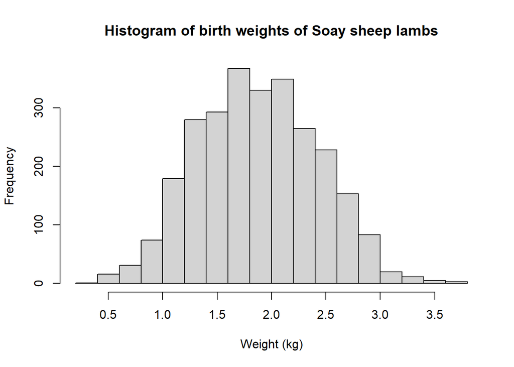

```r
hist(births$BirthWtCorrected, xlab="Weight (kg)",main="Histogram of birth weights of Soay sheep lambs")
```

We will now save a list of phenotypes, fixed Effects_50K and random Effects_50K.

```r
BirthweightPhenotypes <- cbind(rep(1,nrow(births)),as.character(births$ID),as.character(births$BirthWtCorrected))

BirthweightAssoc <- cbind(rep(1,nrow(births)),as.character(births$ID),births$Sex,births$SibCount)

BirthweightQAssoc <-cbind(rep(1,nrow(births)),as.character(births$ID),births$VillTotal,births$MumAge,births$MumAge2,births$Date)

BirthweightRandom <-cbind(rep(1,nrow(births)),as.character(births$ID),births$BirthYear,births$MumID)
colnames(BirthweightRandom) <- c("FID","IID","BirthYear","MumID")


write.table(BirthweightPhenotypes,file="C:/Users/s1944058/Documents/Sheep/R/BirthWeight/BirthWtPhenotypes.txt",row.names = F,col.names = F,quote = F)

write.table(BirthweightAssoc,file="C:/Users/s1944058/Documents/Sheep/R/BirthWeight/BirthWtAssoc.txt",row.names = F,col.names = F,quote = F)

write.table(BirthweightQAssoc,file="C:/Users/s1944058/Documents/Sheep/R/BirthWeight/BirthWtQAssoc.txt",row.names = F,col.names = F,quote = F)

write.table(BirthweightRandom,file="C:/Users/s1944058/Documents/Sheep/R/BirthWeight/BirthWtRandom.txt",row.names = F,col.names = T,quote = F)
```

## Heritability Estimates

### 50K

> #!/bin/sh  
> #$ -cwd  
> #$ -l h_rt=1:00:00  
> #$ -pe sharedmem 1  
> #$ -l h_vmem=100G  
> #$ -M s1944058@sms.ed.ac.uk  
> #$ -m baes  
> . /etc/profile.d/modules.sh

> module load igmm/apps/dissect/1.15.2c  
> module load igmm/apps/plink/1.90b4

> mpirun -np 8 dissect.mpich --reml --bfile ../InputData/Plates_1to87_QC3 --pheno BirthWtPhenotypes.txt --pheno-col 1 --blue --covar BirthWtAssoc.txt --qcovar BirthWtQAssoc.txt --random-effects BirthWtRandom.txt --random-effects-cols 1 2 --out 50K/BirthWt_50K_H2

> if [[ -f 50K/BirthWt_50K_H2.badsnps ]]  
> then  
> plink --bfile ../InputData/Plates_1to87_QC3 --sheep -- exclude 50K/BirthWt_50K_H2.badsnps --make-bed -- out 50K/BirthWt_50K_H2

> mpirun -np 8 dissect.mpich --reml --bfile 50K/BirthWt_50K_H2 --pheno BirthWtPhenotypes.txt --pheno-col 1 --blue --covar BirthWtAssoc.txt --qcovar BirthWtQAssoc.txt --random-effects BirthWtRandom.txt --random-effects-cols 1 2 --out 50K/BirthWt_50K_H2  
> fi

> mpirun -np 8 dissect.mpich --reml --bfile ../InputData/Plates_1to87_QC3 --pheno BirthWtPhenotypes.txt --pheno-col 1 --blue --random-effects BirthWtRandom.txt --random-effects-cols 1 2 --out 50K/BirthWt_50K_TotalPhenotypeVariance

> if [[ -f 50K/BirthWt_50K_TotalPhenotypeVariance.badsnps ]]  
> then  
> plink --bfile ../InputData/Plates_1to87_QC3 --sheep -- exclude 50K/BirthWt_50K_TotalPhenotypeVariance.badsnps --make-bed -- out 50K/BirthWt_50K_TotalPhenotypeVariance

> mpirun -np 8 dissect.mpich --reml --bfile 50K/BirthWt_50K_TotalPhenotypeVariance --pheno BirthWtPhenotypes.txt --pheno-col 1 --blue --random-effects BirthWtRandom.txt --random-effects-cols 1 2 --out 50K/BirthWt_50K_TotalPhenotypeVariance  
> fi

```r
FixedEffects_50K
```

```
##              NAME        BETA         STD
## 1             Sex -0.10616800 0.014407800
## 2           Twins -0.80971800 0.020789700
## 3        Triplets -1.11575000 0.361689000
## 4 Population size -0.00155925 0.000250978
## 5         Mum Age  0.37698100 0.011162400
## 6       Mum Age^2 -0.02834100 0.001011130
## 7            Date  0.00762213 0.001383950
```

```r
RandomEffects_50K
```

```
##                            NAME      BETA        STD
## 1:                  Var(GRM_p1) 0.0115003 0.00404218
## 2:            Var(BirthYear_p1) 0.0266506 0.00758329
## 3:                Var(MumID_p1) 0.0416559  0.0045707
## 4:                    Var(E_p1)   0.10942  0.0043939
## 5: Var(GRM_p1)/Var(Phenotype_1) 0.0607753  0.0213001
```

### HD

> #!/bin/sh  
> #$ -cwd  
> #$ -l h_rt=1:00:00  
> #$ -pe sharedmem 1  
> #$ -l h_vmem=100G  
> #$ -M s1944058@sms.ed.ac.uk  
> #$ -m baes  
> . /etc/profile.d/modules.sh

> module load igmm/apps/dissect/1.15.2c  
> module load igmm/apps/plink/1.90b4

> mpirun -np 8 dissect.mpich --reml --bfile ../InputData/sheep_geno_imputed_oar31_17052020 --pheno BirthWtPhenotypes.txt --pheno-col 1 --blue --covar BirthWtAssoc.txt --qcovar BirthWtQAssoc.txt --random-effects BirthWtRandom.txt --random-effects-cols 1 2 --out HD/BirthWt_HD_H2

> if [[ -f HD/BirthWt_HD_H2.badsnps ]]  
> then  
> plink --bfile ../InputData/sheep_geno_imputed_oar31_17052020 --sheep -- exclude HD/BirthWt_HD_H2.badsnps --make-bed -- out HD/BirthWt_HD_H2

> mpirun -np 8 dissect.mpich --reml --bfile HD/BirthWt_HD_H2 --pheno BirthWtPhenotypes.txt --pheno-col 1 --blue --covar BirthWtAssoc.txt --qcovar BirthWtQAssoc.txt --random-effects BirthWtRandom.txt --random-effects-cols 1 2 --out HD/BirthWt_HD_H2  
> fi

> mpirun -np 8 dissect.mpich --reml --bfile ../InputData/sheep_geno_imputed_oar31_17052020 --pheno BirthWtPhenotypes.txt --pheno-col 1 --blue --random-effects BirthWtRandom.txt --random-effects-cols 1 2 --out HD/BirthWt_HD_TotalPhenotypeVariance

> if [[ -f HD/BirthWt_HD_TotalPhenotypeVariance.badsnps ]]  
> then  
> plink --bfile ../InputData/sheep_geno_imputed_oar31_17052020 --sheep -- exclude HD/BirthWt_HD_TotalPhenotypeVariance.badsnps --make-bed -- out HD/BirthWt_HD_TotalPhenotypeVariance

> mpirun -np 8 dissect.mpich --reml --bfile HD/BirthWt_HD_TotalPhenotypeVariance --pheno BirthWtPhenotypes.txt --pheno-col 1 --blue --random-effects BirthWtRandom.txt --random-effects-cols 1 2 --out HD/BirthWt_HD_TotalPhenotypeVariance  
> fi

```r
FixedEffects_HD
```

```
##              NAME        BETA         STD
## 1             Sex -0.10635200 0.014346900
## 2           Twins -0.80941400 0.020793500
## 3        Triplets -1.11089000 0.362210000
## 4 Population size -0.00155998 0.000251189
## 5         Mum Age  0.37687000 0.011168900
## 6       Mum Age^2 -0.02832820 0.001011760
## 7            Date  0.00758970 0.001384650
```

```r
RandomEffects_HD
```

```
##                            NAME      BETA        STD
## 1:                  Var(GRM_p1) 0.0103782 0.00394938
## 2:            Var(BirthYear_p1) 0.0267108 0.00759756
## 3:                Var(MumID_p1) 0.0417865 0.00457616
## 4:                    Var(E_p1)  0.110213 0.00439392
## 5: Var(GRM_p1)/Var(Phenotype_1) 0.0548853  0.0208525
```

### GWAS

> #!/bin/sh  
> #$ -cwd  
> #$ -l h_rt=2:00:00  
> #$ -pe sharedmem 1  
> #$ -l h_vmem=200G  
> #$ -t 1-26  
> #$ -tc 5  
> #$ -M s1944058@sms.ed.ac.uk  
> #$ -m baes  
> . /etc/profile.d/modules.sh

> module load igmm/apps/dissect/1.15.2c  
> module load igmm/apps/plink/1.90b4

> i=$_TASK_ID

> plink --bfile ../InputData/Plates_1to87_QC3 --sheep --not-chr ${i},X --keep BirthWtPhenotypes.txt --make-bed --out 50K/NoChr${i}

> mpirun -np 8 dissect.mpich --make-grm --bfile 50K/NoChr${i} --out 50K/NoChr${i}_GRM

> echo "50K/Chr${i} 50K/NoChr${i}_GRM" > 50K/GWAS_GRM${i}.txt

> plink --bfile ../InputData/Plates_1to87_QC3 --sheep --chr ${i} --keep BirthWtPhenotypes.txt --make-bed --out 50K/Chr${i}

> if [[ -f 50K/NoChr${i}_GRM.badsnps ]]  
> then  
> plink --bfile 50K/NoChr${i} --sheep --exclude 50K/NoChr${i}_GRM.badsnps --make-bed --out 50K/NoChr${i}_2

> mpirun -np 8 dissect.mpich --make-grm --bfile 50K/NoChr${i}_2 --out 50K/NoChr${i}_GRM

> fi

> mpirun -np 8 dissect.mpich --gwas --bfile-grm-list 50K/GWAS_GRM${i}.txt --pheno BirthWtPhenotypes.txt --covar BirthWtAssoc.txt --qcovar BirthWtQAssoc.txt --random-effects BirthWtRandom.txt --random-effects-cols 1,2 --out 50K/BirthWt_50K_GWAS_Chr${i}

> if [[ -f 50K/BirthWt_50K_GWAS_Chr${i}.badsnps ]]  
> then  
> plink --bfile 50K/Chr${i} --sheep --exclude 50K/BirthWt_50K_GWAS_Chr${i}.badsnps --make-bed --out 50K/Chr${i}_2

> echo "50K/Chr${i}_2 50K/NoChr${i}_GRM" > 50K/GWAS_GRM${i}.txt

> mpirun -np 8 dissect.mpich --gwas --bfile-grm-list 50K/GWAS_GRM${i}.txt --pheno BirthWtPhenotypes.txt --covar BirthWtAssoc.txt --qcovar BirthWtQAssoc.txt --random-effects BirthWtRandom.txt --random-effects-cols 1,2 --out 50K/BirthWt_50K_GWAS_Chr${i}  
> fi

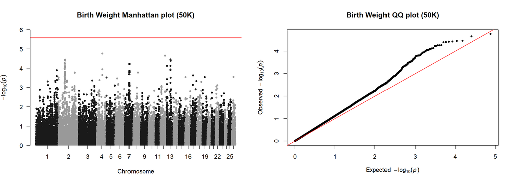

```r
files = list.files(pattern="BirthWt_50K_GWAS_Chr",recursive=TRUE)

SNPresults = do.call(rbind, lapply(files, function(x) read.table(x,header=T)))

bimFile <- read.table("C:/Users/s1944058/Documents/Sheep/50KSNP/Plates_1to87_QC3.bim",header=F)

GWAS50KResults <- merge(bimFile,SNPresults[,c("SNP","PV"),],by.x="V2",by.y="SNP",all.x=FALSE,all.y=TRUE)
colnames(GWAS50KResults) <- c("SNP","Chr","V3","Pos","Ref","Minor","PV")
GWAS50KResults$Chr <- as.numeric(GWAS50KResults$Chr)
par(mfrow=c(1,2))
manhattan(GWAS50KResults,chr="Chr",bp="Pos",p="PV",snp="SNP", main = "Birth Weight Manhattan plot (50K)", genomewideline = -log10(0.05/20082),suggestiveline = FALSE,ylim=c(0,6))
qq(GWAS50KResults$PV,main="Birth Weight QQ plot (50K)")
```

**None of the SNPs are signficant!**

### Imputed SNP data

> #!/bin/sh  
> #$ -cwd  
> #$ -l h_rt=3:00:00  
> #$ -pe sharedmem 1  
> #$ -l h_vmem=200G  
> #$ -t 1-26  
> #$ -tc 5  
> #$ -M s1944058@sms.ed.ac.uk  
> #$ -m baes  
> . /etc/profile.d/modules.sh

> module load igmm/apps/dissect/1.15.2c  
> module load igmm/apps/plink/1.90b4

> i=$_TASK_ID

> plink --bfile ../InputData/sheep_geno_imputed_oar31_17052020 --sheep --not-chr ${i},X --keep BirthWtPhenotypes.txt --make-bed --out HD/NoChr${i}

> mpirun -np 8 dissect.mpich --make-grm --bfile HD/NoChr${i} --out HD/NoChr${i}_GRM

> echo "HD/Chr${i} HD/NoChr${i}_GRM" > HD/GWAS_GRM${i}.txt

> plink --bfile ../InputData/sheep_geno_imputed_oar31_17052020 --sheep --chr ${i} --keep BirthWtPhenotypes.txt --make-bed --out HD/Chr${i}

> if [[ -f HD/NoChr${i}_GRM.badsnps ]]  
> then  
> plink --bfile HD/NoChr${i} --sheep --exclude HD/NoChr${i}_GRM.badsnps --make-bed --out HD/NoChr${i}_2

> mpirun -np 8 dissect.mpich --make-grm --bfile HD/NoChr${i}_2 --out HD/NoChr${i}_GRM

> fi

> mpirun -np 8 dissect.mpich --gwas --bfile-grm-list HD/GWAS_GRM${i}.txt --pheno BirthWtPhenotypes.txt --covar BirthWtAssoc.txt --qcovar BirthWtQAssoc.txt --random-effects BirthWtRandom.txt --random-effects-cols 1,2 --out HD/BirthWt_HD_GWAS_Chr${i}

> if [[ -f HD/BirthWt_HD_GWAS_Chr${i}.badsnps ]]  
> then  
> plink --bfile HD/Chr${i} --sheep --exclude HD/BirthWt_HD_GWAS_Chr${i}.badsnps --make-bed --out HD/Chr${i}_2

> echo "HD/Chr${i}_2 HD/NoChr${i}_GRM" > HD/GWAS_GRM${i}.txt

> mpirun -np 8 dissect.mpich --gwas --bfile-grm-list HD/GWAS_GRM${i}.txt --pheno BirthWtPhenotypes.txt --covar BirthWtAssoc.txt --qcovar BirthWtQAssoc.txt --random-effects BirthWtRandom.txt --random-effects-cols 1,2 --out HD/BirthWt_HD_GWAS_Chr${i}  
> fi

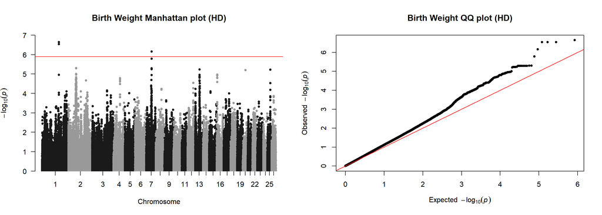

```r
files = list.files(pattern="BirthWt_HD_GWAS_Chr",recursive=TRUE)

SNPresults = do.call(rbind, lapply(files, function(x) read.table(x,header=T)))

bimFile <- read.table("C:/Users/s1944058/Documents/Sheep/HDSNP/sheep_geno_imputed_oar31_17052020.bim",header=F)

GWASHDResults <- merge(bimFile,SNPresults[,c("SNP","PV"),],by.x="V2",by.y="SNP",all.x=FALSE,all.y=TRUE)
colnames(GWASHDResults) <- c("SNP","Chr","V3","Pos","Ref","Minor","PV")
GWASHDResults$Chr <- as.numeric(GWASHDResults$Chr)
par(mfrow=c(1,2))
manhattan(GWASHDResults,chr="Chr",bp="Pos",p="PV",snp="SNP", main = "Birth Weight Manhattan plot (HD)", genomewideline = -log10(0.05/39149),suggestiveline = FALSE)
qq(GWASHDResults$PV,main="Birth Weight QQ plot (HD)")
```

```r
SNPs <- GWASHDResults[which(GWASHDResults$PV < (0.05/39149) ),c("Chr","Pos","SNP","PV")]
SNPs[order(SNPs$PV),]
```

```
##        Chr       Pos                 SNP         PV
## 32051    1 175180452 oar3_OAR1_175180452 2.2672e-07
## 32044    1 175153253 oar3_OAR1_175153253 2.8887e-07
## 32045    1 175158214 oar3_OAR1_175158214 2.8887e-07
## 32046    1 175158303 oar3_OAR1_175158303 2.8887e-07
## 361855   7  55685759  oar3_OAR7_55685759 6.9074e-07
```

## **FINAL RESULTS**

### 50K

```r
RandomEffects_50K[nrow(RandomEffects_50K),]
```

```
##                            NAME      BETA       STD
## 1: Var(GRM_p1)/Var(Phenotype_1) 0.0607753 0.0213001
```

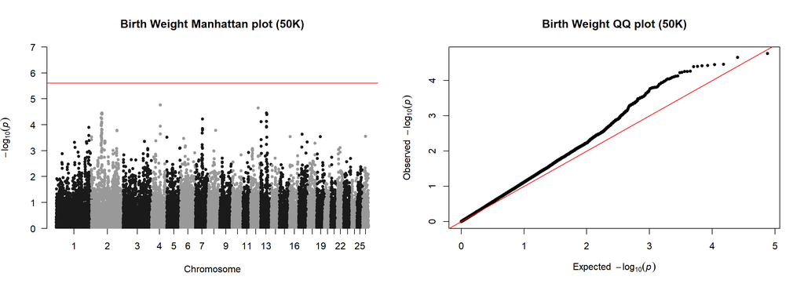

```r
par(mfrow=c(1,2))
manhattan(GWAS50KResults,chr="Chr",bp="Pos",p="PV",snp="SNP", main = "Birth Weight Manhattan plot (50K)", genomewideline = -log10(0.05/20082),suggestiveline = FALSE,ylim=c(0,7))
qq(GWAS50KResults$PV,main="Birth Weight QQ plot (50K)")
```

### HD

```r
RandomEffects_HD[nrow(RandomEffects_HD),]
```

```
##                            NAME      BETA       STD
## 1: Var(GRM_p1)/Var(Phenotype_1) 0.0548853 0.0208525
```

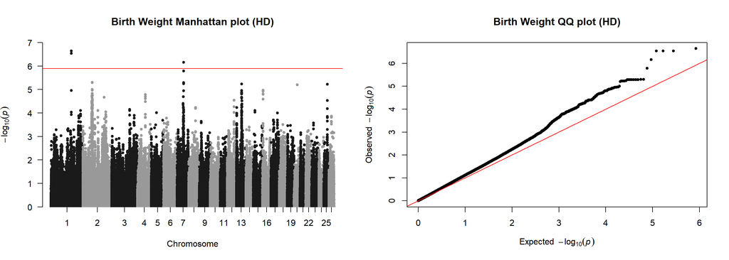

```r
par(mfrow=c(1,2))
manhattan(GWASHDResults,chr="Chr",bp="Pos",p="PV",snp="SNP", main = "Birth Weight Manhattan plot (HD)", genomewideline = -log10(0.05/39149),suggestiveline = FALSE)
qq(GWASHDResults$PV,main="Birth Weight QQ plot (HD)")
```